# Linear Regression

In an ideal world, you would want every data point relevant to the question you are trying to answer. In a previous course, you learned that data professionals describe this as population.

Let’s imagine you’re working for a publishing company. You want to understand the relationship between an author’s social media following, and their book sales. You would need data on every book author, social media follower count, and every book sale of all time. This is an impossible task, but luckily, you don’t actually need an entire population to run meaningful regression analysis. You can get a reasonable estimate with a representative sample.

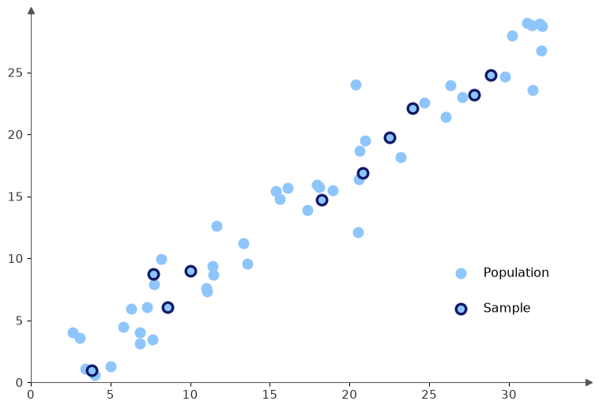

```python
import numpy as np
import matplotlib.pyplot as plt

# Set random seed for reproducible data points
np.random.seed(42)

# Generate synthetic population data following a positive linear trend
n_points = 55
x = np.random.uniform(2, 33, n_points)
y = 0.85 * x + np.random.normal(0, 2, n_points)

# Select a subset of indices to represent the sample
sample_indices = np.random.choice(n_points, size=10, replace=False)

# Create mask for population (non-sampled) points
pop_mask = np.ones(n_points, dtype=bool)
pop_mask[sample_indices] = False

# Set up the plot styling
plt.figure(figsize=(8, 5.5), facecolor='white')
ax = plt.gca()

# Remove top and right spines to match the original layout
ax.spines['top'].set_visible(False)
ax.spines['right'].set_visible(False)
ax.spines['left'].set_color('#555555')
ax.spines['bottom'].set_color('#555555')

# Plot Population points (light blue)
plt.scatter(
    x[pop_mask], y[pop_mask],
    color='#8ec5fc',
    s=90,
    label='Population',
    zorder=2
)

# Plot Sample points (light blue with dark navy outline)
plt.scatter(
    x[sample_indices], y[sample_indices],
    color='#8ec5fc',
    edgecolor='#0f1b67',
    linewidth=2.5,
    s=90,
    label='Sample',
    zorder=3
)

# Set axis limits & ticks matching the image
plt.xlim(0, 35)
plt.ylim(0, 30)
plt.xticks(np.arange(0, 35, 5), fontsize=11, color='#333333')
plt.yticks(np.arange(0, 30, 5), fontsize=11, color='#333333')

# Add arrow heads to the axes
ax.plot(1, 0, ">k", transform=ax.get_yaxis_transform(), clip_on=False, color='#555555')
ax.plot(0, 1, "^k", transform=ax.get_xaxis_transform(), clip_on=False, color='#555555')

# Customizing legend appearance and placement
plt.legend(
    loc='lower right',
    bbox_to_anchor=(0.95, 0.15),
    frameon=False,
    fontsize=12,
    labelspacing=1.8
)

plt.tight_layout()
plt.show()
```

A sample is a part of the population, which is just the statistical way of saying a sample is some of the data you could possibly have. If you have a set of sample data, each data point can be represented with its own set of attributes or $x$ and $y$ values. In that case, the sample does not contain all possible values from the population of data. The observed values or actual values, are the existing sample of data. **Each data point in this sample is represented by an observed value of the dependent variable and an observed value of the independent variable.** In the publishing company example, the dependent variable is book sales, and the independent variable is how many followers the author has on social media. An observed value you might have in your dataset would be $x$ or number of followers equals 10,000, and $y$ or number of books sales equals 500. The goal of the regression analysis is to define a relationship mathematically between the sample Ys and Xs to understand how the two variables interact.

You can imagine that at every $x$ value, there are many possible values that $y$ can take on. To simplify this understanding, linear regression analysis focuses on the mean of $y$ given a particular value of $x$. This mean of $y$ is the value on the line in a linear regression and is denoted with the Greek letter that looks like a lowercase m $\mu$. You can remember m is for mean. The Greek symbol is mu.

As described previously, in order to define a linear relationship, we need a slope and an intercept. In statistics, we write the intercept as $\beta_0$, which we sometimes call Beta naught, and the slope is written as $\beta_1$

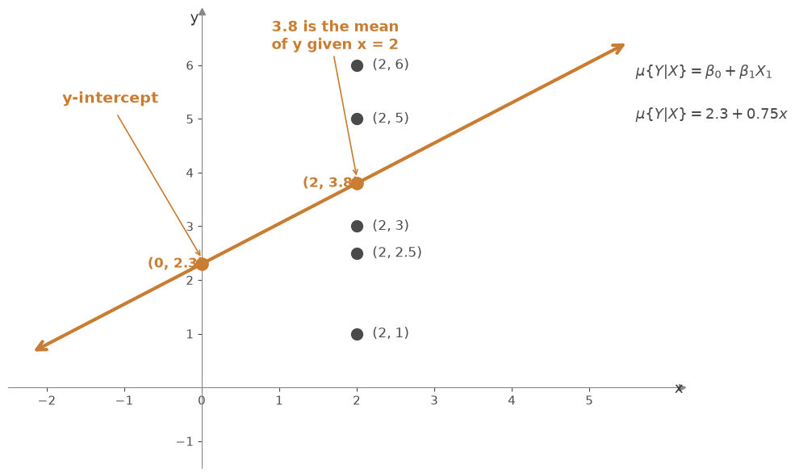

```python
import matplotlib.pyplot as plt
import numpy as np

# Setup figure
fig, ax = plt.subplots(figsize=(10, 6), dpi=100)

# 1. Regression Line Data: y = 2.3 + 0.75x
x_line = np.linspace(-2.2, 5.5, 100)
y_line = 2.3 + 0.75 * x_line

# 2. Data Points at x = 2
x_pts = [2, 2, 2, 2, 2]
y_pts = [6, 5, 3, 2.5, 1]

# Plot data points (dark grey)
ax.scatter(x_pts, y_pts, color='#4a4a4a', s=100, zorder=4)

# Plot points of interest on the regression line (brown/orange)
ax.scatter([0, 2], [2.3, 3.8], color='#c87d32', s=120, zorder=5)

# Plot regression line with double-sided arrow styling
ax.annotate('', xy=(5.5, 2.3 + 0.75 * 5.5), xytext=(-2.2, 2.3 + 0.75 * -2.2),
            arrowprops=dict(arrowstyle='<->', color='#c87d32', lw=3, mutation_scale=20))

# 3. Text labels for data points
for x_val, y_val in zip(x_pts, y_pts):
    ax.text(x_val + 0.2, y_val, f'({x_val}, {y_val})', fontsize=12, color='#4a4a4a', va='center')

# Label for y-intercept and mean point
ax.text(-0.7, 2.3, '(0, 2.3)', fontsize=12, color='#c87d32', fontweight='bold', va='center')
ax.text(1.3, 3.8, '(2, 3.8)', fontsize=12, color='#c87d32', fontweight='bold', va='center')

# 4. Annotations & Arrows
# y-intercept annotation
ax.text(-1.8, 5.3, 'y-intercept', fontsize=14, color='#c87d32', fontweight='bold')
ax.annotate('', xy=(0, 2.4), xytext=(-1.1, 5.1),
            arrowprops=dict(arrowstyle='->', color='#c87d32', lw=1.2))

# Mean of y given x = 2 annotation
ax.text(0.9, 6.3, '3.8 is the mean\nof y given x = 2', fontsize=13, color='#c87d32', fontweight='bold')
ax.annotate('', xy=(2, 3.9), xytext=(1.7, 6.2),
            arrowprops=dict(arrowstyle='->', color='#c87d32', lw=1.2))

# Equations on top-right
ax.text(5.6, 5.8, r'$\mu\{Y|X\} = \beta_0 + \beta_1 X_1$', fontsize=13, color='#4a4a4a')
ax.text(5.6, 5.0, r'$\mu\{Y|X\} = 2.3 + 0.75x$', fontsize=13, color='#4a4a4a')

# 5. Centered Axis Lines with Arrowheads
ax.spines['left'].set_position('zero')
ax.spines['bottom'].set_position('zero')
ax.spines['right'].set_color('none')
ax.spines['top'].set_color('none')
ax.spines['left'].set_color('#888888')
ax.spines['bottom'].set_color('#888888')

# Axis arrowheads & labels
ax.plot(1, 0, ">k", transform=ax.get_yaxis_transform(), clip_on=False, color='#888888')
ax.plot(0, 1, "^k", transform=ax.get_xaxis_transform(), clip_on=False, color='#888888')
ax.text(6.1, -0.1, 'x', fontsize=13, color='#333333')
ax.text(-0.15, 6.8, 'y', fontsize=13, color='#333333')

# Ticks configuration
ax.set_xticks([-2, -1, 0, 1, 2, 3, 4, 5])
ax.set_yticks([-1, 1, 2, 3, 4, 5, 6])
ax.tick_params(colors='#4a4a4a', labelsize=11)

# Axis Limits
ax.set_xlim(-2.5, 6.2)
ax.set_ylim(-1.5, 7.0)

plt.tight_layout()
plt.show()
```

$\mu$ of $y$ and the Betas are sometimes called parameters. **Parameters are properties of populations and not samples.**
$$\mu{Y|X} = \beta_0 + \beta_1 X$$

We can never know their true value since we can’t observe the whole population. But we can calculate estimates of the parameters using our sample data. To differentiate between the population parameters and the estimates of the parameters, we denote the estimates with the hat.

$$\hat{\mu}\{Y|X\} = \hat{\beta_0} + \hat{\beta_1} X$$

For example, let’s say that we estimate $hat{\beta_0}$ as negative 1 and $hat{\beta_1}$ as five. Now let’s input some values for $x$. If $x$ equals 0, we get negative 1, which is the $y$-intercept or $hat{\beta_0}$. If $x$ equals 1, we get $y$ equals 4. If $x$ equals 2, we get $y$ equals 9. If $x$ equals 3, we get $y$ equals 14.

From just four data points, a pattern emerges. For every one unit increase in $x$, we get a five unit increase in $y$.

Remembering our equation, five is our slope or Beta 1. The slope tells us how much $y$ increases for every one unit increase in $x$. These estimated Betas are also called **regression coefficients**. Now, whenever you see the hat symbol, you’ll know that you are estimating Betas, also known as regression coefficients.

In the prior formula, the regression coefficients were the slope and intercept, they described the linear relationship found in the sample data. In order to enter values of $x$ and get estimated values for $y$, we assumed that Beta 0 was negative 1 and that Beta 1 was five. But how did we arrive at those regression coefficients? One of the most common ways to calculate linear regression coefficients is **ordinary least squares estimation**, or **OLS** for short. We will go over the math behind OLS later in the course. For now though, let’s discuss an overview of how OLS works.